# Machine Learning Project

Dave Ingram

January 25, 2015

# Executive Summary

The goal of this project is to predict the manner in which participants performed a particular excercise. Participants were asked to perform barbell lifts correctly and incorrectly in 5 different ways, and the results were measured using data from accelerometers on the belt, forearm, arm, and dumbell of 6 participants.

Multiple prediction models were evaluated, including Boosting, Classification Trees and Random Forrests. The in-sample and out-of-sample error rate was then calculated for cross validation and the best model chosen.

The most effective model was a Random Forrests model with an out-of-sample cross validation estimate of 98.9%.

# Data Processing

In order to build the model, the training data was split into a training set of 75% and a test set of %25 of the original data. The training set was again split to have a smaller exploration set due to computational complexity of several models. We also loaded the 20 value test set as a validation set.

# Pre-processing and exploration

The first thing of interest is winnowing out variables of the 160 in the set that are of no use for prediction. We do this by first removing the variables with Near Zero Variance, then also removing the “X” variable which is unique per row. It was also expected that the timestamp variables are uncorrelated with class, but this was verified prior to removing these from the predictors. Finally, a smaller dataset was sampled from the training set for computational ease when exploring the data relationships further.

Given the large number of potential features, a number of exploratory techniques were considered. The predictors included a wide range of numeric, integer and factor variables, making a simple principal component analysis more challenging. Therefore, we first isolate only the numeric predictors, then run a principal component analysis on those.

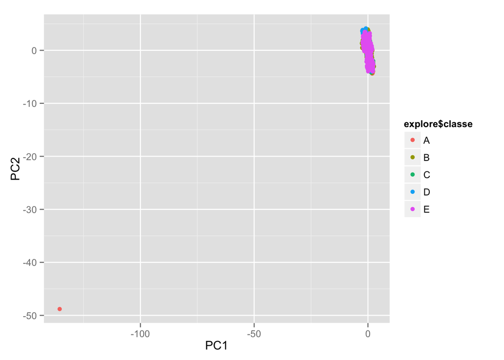

```r
numericCols <- data.frame(classe = explore$classe)
names <- "classe"
for(i in 1:length(explore[1,])) {
    if(class(explore[,i]) == "numeric") {
        numericCols <- data.frame(numericCols, explore[,i])
        names <- c(names, names(explore)[i])
    }
}
colnames(numericCols) <- names
#pcaModel = train(classe ~ ., data=numericCols, preProcess=c('pca'), thresh=.8)

# Generate a model with 2 principal coponents
pcaModel2 = preProcess(numericCols[,-1], method=c('pca'), pcaComp = 2)
pcs <- predict(pcaModel2, numericCols[,-1])
qplot(PC1, PC2, data=pcs, color=explore$classe)
```

Initial exploration of using principal components did not yield a strong relationship with prediction, so latter models are built without using pca.

```r
library(rattle)
library(rpart)

treeFit <- train(classe ~ ., data=training, method="rpart")
```

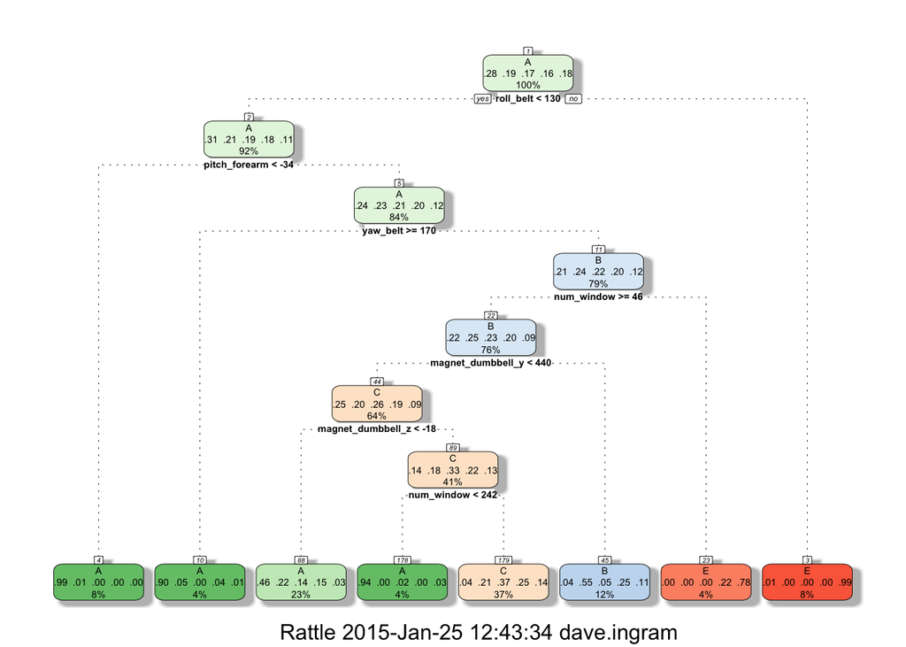

```r
fancyRpartPlot(treeFit$finalModel)
```

The final model in this classification tree generated a 58% accuracy and highlighted several very useful variables for prediction.

# Model Selection and Cross Validation

```r
rfFit <- train(classe ~., data=explore, method="rf")
#confusionMatrix(predict(modelFit, testing), testing$classe)
rfFit$results
```

```
##   mtry Accuracy  Kappa AccuracySD  KappaSD
## 1    2   0.9657 0.9566   0.005729 0.007238
## 2   27   0.9782 0.9723   0.003841 0.004877
## 3   53   0.9750 0.9683   0.004345 0.005509
```

```r
confusionMatrix(predict(rfFit, testing), testing$classe)
```

```
## Confusion Matrix and Statistics
##
##           Reference
## Prediction    A    B    C    D    E
##          A 1395    4    0    0    0
##          B    0  936    7    0    1
##          C    0    9  844   11    4
##          D    0    0    4  790    9
##          E    0    0    0    3  887
##
## Overall Statistics
##
##                Accuracy : 0.989
##                  95% CI : (0.986, 0.992)
##     No Information Rate : 0.284
##     P-Value [Acc > NIR] : <2e-16
##
##                   Kappa : 0.987
##  Mcnemar's Test P-Value : NA
##
## Statistics by Class:
##
##                      Class: A Class: B Class: C Class: D Class: E
## Sensitivity             1.000    0.986    0.987    0.983    0.984
## Specificity             0.999    0.998    0.994    0.997    0.999
## Pos Pred Value          0.997    0.992    0.972    0.984    0.997
## Neg Pred Value          1.000    0.997    0.997    0.997    0.997
## Prevalence              0.284    0.194    0.174    0.164    0.184
## Detection Rate          0.284    0.191    0.172    0.161    0.181
## Detection Prevalence    0.285    0.192    0.177    0.164    0.181
## Balanced Accuracy       0.999    0.992    0.991    0.990    0.992
```

This model was further compared with a boosting algorithm.

```r
gbmFit <- train(classe ~., data=explore, method="gbm", verbose=F)
gbmFit$results
```

```
##   shrinkage interaction.depth n.trees Accuracy  Kappa AccuracySD  KappaSD
## 1       0.1                 1      50   0.7515 0.6848   0.012634 0.015775
## 4       0.1                 2      50   0.8663 0.8306   0.008455 0.010678
## 7       0.1                 3      50   0.9125 0.8891   0.008350 0.010580
## 2       0.1                 1     100   0.8144 0.7650   0.010948 0.013847
## 5       0.1                 2     100   0.9185 0.8968   0.007672 0.009702
## 8       0.1                 3     100   0.9482 0.9344   0.005785 0.007323
## 3       0.1                 1     150   0.8495 0.8094   0.008604 0.010952
## 6       0.1                 2     150   0.9394 0.9233   0.005634 0.007124
## 9       0.1                 3     150   0.9630 0.9531   0.004984 0.006319
```

```r
confusionMatrix(predict(gbmFit, testing), testing$classe)
```

```
## Confusion Matrix and Statistics
##
##           Reference
## Prediction    A    B    C    D    E
##          A 1383   27    0    2    2
##          B    6  902   11    2    5
##          C    0   19  836   15    3
##          D    1    0    7  779   18
##          E    5    1    1    6  873
##
## Overall Statistics
##
##                Accuracy : 0.973
##                  95% CI : (0.968, 0.978)
##     No Information Rate : 0.284
##     P-Value [Acc > NIR] : <2e-16
##
##                   Kappa : 0.966
##  Mcnemar's Test P-Value : NA
##
## Statistics by Class:
##
##                      Class: A Class: B Class: C Class: D Class: E
## Sensitivity             0.991    0.950    0.978    0.969    0.969
## Specificity             0.991    0.994    0.991    0.994    0.997
## Pos Pred Value          0.978    0.974    0.958    0.968    0.985
## Neg Pred Value          0.997    0.988    0.995    0.994    0.993
## Prevalence              0.284    0.194    0.174    0.164    0.184
## Detection Rate          0.282    0.184    0.170    0.159    0.178
## Detection Prevalence    0.288    0.189    0.178    0.164    0.181
## Balanced Accuracy       0.991    0.972    0.984    0.981    0.983
```

Boosting also performed quite well, yielding a 97.3% accuracy on out-of-sample prediction.

# Summary

While over half of the possible features were found to be either incomplete or not useful for prediction, we were able to build a prediction algorithm with over 98.9% accuracy. Of the models tested, a Random Forrest algorithm proved to be the most useful. Using a simple classification tree, we also learned that a much smaller number of variables had the highest predictive value, which may be valuable for future applications which may wish to collect a smaller number of features.